# Priyanka_Chitikela_8909667_Practical_Lab1

## Practical Lab1: Univariate Linear Regression on the California Housing Prices Dataset

- **Student Name** : Priyanka Chitikela
- **Student ID** : 8909667
- **Section**: 1

### **Step-1: Describe the goal of this report**

The goal of this report is to build three linear regression models using data from the California Housing Prices dataset. The data includes information about houses, the population, and the economy in different California districts.

In this report, we will try to predict the median house value using three different independent variables:

1. **Median Income**: The average income of people in the district.
2. **Population**: The total number of people living in the district.
3. **Number of Households**: The number of households in the district.

By building these models, we want to understand how each of these factors affects the house prices and gain some practical experience with basic machine learning techniques.

### **Step-2: Getting the Data**

**Dataset Source**: The California Housing Prices dataset is available in Kaggle Datasets.

**Dataset link**: https://www.kaggle.com/datasets/camnugent/california-housing-prices

##### Loading Dataset into Pandas:

```python
# import pandas library
import pandas as pd
# Read the dataset that is downloaded from kaggle
data_housing = pd.read_csv(r'.\data\housing.csv')
data_housing.head()
```

|  | longitude | latitude | housing_median_age | total_rooms | total_bedrooms | population | households | median_income | median_house_value | ocean_proximity |
| --- | --- | --- | --- | --- | --- | --- | --- | --- | --- | --- |
| 0 | -122.23 | 37.88 | 41.0 | 880.0 | 129.0 | 322.0 | 126.0 | 8.3252 | 452600.0 | NEAR BAY |
| 1 | -122.22 | 37.86 | 21.0 | 7099.0 | 1106.0 | 2401.0 | 1138.0 | 8.3014 | 358500.0 | NEAR BAY |
| 2 | -122.24 | 37.85 | 52.0 | 1467.0 | 190.0 | 496.0 | 177.0 | 7.2574 | 352100.0 | NEAR BAY |
| 3 | -122.25 | 37.85 | 52.0 | 1274.0 | 235.0 | 558.0 | 219.0 | 5.6431 | 341300.0 | NEAR BAY |
| 4 | -122.25 | 37.85 | 52.0 | 1627.0 | 280.0 | 565.0 | 259.0 | 3.8462 | 342200.0 | NEAR BAY |

The above code imports the dataset and converts it into a Pandas DataFrame so we can easily work with it.

### **Step-3: Exploratory Data Analysis (EDA)**

##### 1. Explore statistics (e.g. using Pandas **describe** function):

```python
data_housing.describe()
```

|  | longitude | latitude | housing_median_age | total_rooms | total_bedrooms | population | households | median_income | median_house_value |
| --- | --- | --- | --- | --- | --- | --- | --- | --- | --- |
| count | 20640.000000 | 20640.000000 | 20640.000000 | 20640.000000 | 20433.000000 | 20640.000000 | 20640.000000 | 20640.000000 | 20640.000000 |
| mean | -119.569704 | 35.631861 | 28.639486 | 2635.763081 | 537.870553 | 1425.476744 | 499.539680 | 3.870671 | 206855.816909 |
| std | 2.003532 | 2.135952 | 12.585558 | 2181.615252 | 421.385070 | 1132.462122 | 382.329753 | 1.899822 | 115395.615874 |
| min | -124.350000 | 32.540000 | 1.000000 | 2.000000 | 1.000000 | 3.000000 | 1.000000 | 0.499900 | 14999.000000 |
| 25% | -121.800000 | 33.930000 | 18.000000 | 1447.750000 | 296.000000 | 787.000000 | 280.000000 | 2.563400 | 119600.000000 |
| 50% | -118.490000 | 34.260000 | 29.000000 | 2127.000000 | 435.000000 | 1166.000000 | 409.000000 | 3.534800 | 179700.000000 |
| 75% | -118.010000 | 37.710000 | 37.000000 | 3148.000000 | 647.000000 | 1725.000000 | 605.000000 | 4.743250 | 264725.000000 |
| max | -114.310000 | 41.950000 | 52.000000 | 39320.000000 | 6445.000000 | 35682.000000 | 6082.000000 | 15.000100 | 500001.000000 |

##### 2. Create three Seaborn scatter plots:

To create scatter plots, we should see the relationship between the dependent variable (median house value) and each of the independent variables (median income, population, and number of households). This will help us see if a linear relationship exists, which is important for linear regression.

**Code for Scatter Plots:**

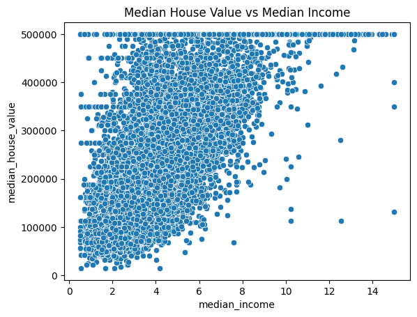

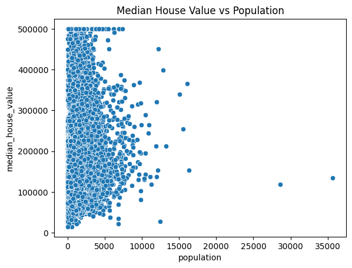

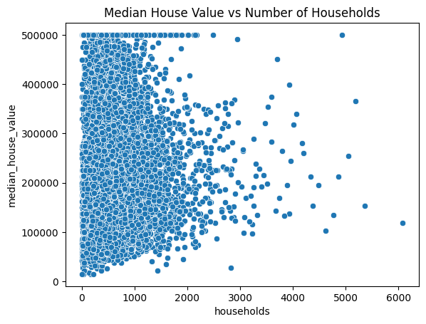

```python
# Import necessary libraries
import seaborn as sns
import matplotlib.pyplot as plt

# Scatter plot for Median House Value vs Median Income
sns.scatterplot(x='median_income', y='median_house_value', data=data_housing)
plt.title('Median House Value vs Median Income')
plt.show()

# Scatter plot for Median House Value vs Population
sns.scatterplot(x='population', y='median_house_value', data=data_housing)
plt.title('Median House Value vs Population')
plt.show()

# Scatter plot for Median House Value vs Number of Households
sns.scatterplot(x='households', y='median_house_value', data=data_housing)
plt.title('Median House Value vs Number of Households')
plt.show()
```

**Interpretation and Insights:**

**Median House Value vs Median Income:** This scatter plot shows a clear pattern, as median income goes up, median house values also increase. This means that wealthier areas usually have more expensive houses. A linear regression model should work well with this data.

**Median House Value vs Population:** The points in this plot are scattered which shows no clear relationship between population and house value. This means population might not be a good predictor of house value, and the linear regression model may not fit well for this data.

**Median House Value vs Number of Households:** This plot is also a bit scattered, showing no strong relationship between the number of households and house value. There might be a weak relationship, but it's not as strong as the one between income and house value.

Based on these insights, median income looks like the most reliable variable for predicting house value.

##### 3. Description of the variables used in this Lab:

**Median Income:**

- **Meaning**: This shows the average income of people living in a district.
- **Range:** It varies from low to high values, reflecting different economic conditions.
- **Characteristics:** Higher median income usually means higher house values, indicating that wealthier areas tend to have more expensive homes.

**Population:**

- **Meaning**: This is the total number of people living in a district.
- **Range:** It can range from small towns to large cities.
- **Characteristics:** The relationship between population size and house values is not strong, suggesting other factors play a bigger role.

**Number of Households:**

- **Meaning**: This counts the total number of households in a district.
- **Range:** Like population, this varies widely based on the size and density of the area.
- **Characteristics:** The connection between the number of households and house values is also weak, indicating it may not be a good predictor for prices.

**Median House Value:**

- **Meaning**: This represents the median price of houses in a district.
- **Range:** The values can vary significantly, reflecting the housing market in California.
- **Characteristics:** This is the main variable we want to predict. It has a strong link to median income, showing that higher incomes lead to higher house values.

### **Step-4: Run Three Linear Regressions**

```python
# import necessary libraries
from sklearn.linear_model import LinearRegression
from sklearn.metrics import mean_squared_error, mean_absolute_error
import pandas as pd

# Initialize a list to store results
results = []

# Function to run regression and calculate metrics
def run_regression(X, y, variable_name):
    model = LinearRegression()
    model.fit(X, y)

    # Predictions
    y_pred = model.predict(X)

    # Calculate metrics
    mse = mean_squared_error(y, y_pred)
    mae = mean_absolute_error(y, y_pred)

    results.append({
        'Variable': variable_name,
        'Intercept': model.intercept_,
        'Slope': model.coef_[0],
        'MSE': mse,
        'MAE': mae
    })

# Prepare data for each regression
# Dependent variable
y = data_housing['median_house_value']
```

1. **Median House Value vs. Median Income:**

```python
X_income = data_housing[['median_income']]
run_regression(X_income, y, 'Median Income')
```

2. **Median House Value vs. Population:**

```python
X_population = data_housing[['population']]
run_regression(X_population, y, 'Population')
```

3. **Median House Value vs. Number of Households:**

```python
X_households = data_housing[['households']]
run_regression(X_households, y, 'Households')
```

### **Step-5: Summary Table of Linear Regression Results**

```python
results_df = pd.DataFrame(results)
print(results_df)
```

```
        Variable      Intercept         Slope           MSE           MAE
0  Median Income   45085.576703  41793.849202  7.011312e+09  62625.933791
1     Population  210436.262076     -2.511753  1.330741e+10  91153.820095
2     Households  196928.577162     19.872775  1.325778e+10  90802.743243
```

**Explanation of the Table:**

**Intercept:** This tells us the predicted median house price when the independent variable (like income) is zero.

**Slope:** This shows how much the median house price changes for a one-unit increase in the independent variable. For example, if the slope for median income is high, it means higher income leads to much higher house prices.

**Mean Squared Error (MSE):** This measures how far the predicted house prices are from the actual prices. Lower values are better.

**Mean Absolute Error (MAE):** This shows the average error in predictions. Like MSE, lower values indicate better predictions.

This table summarizes the performance of each regression model, giving insights into how well each independent variable predicts median house values.

### **Step-6: Plotting the Results with Regression Lines**

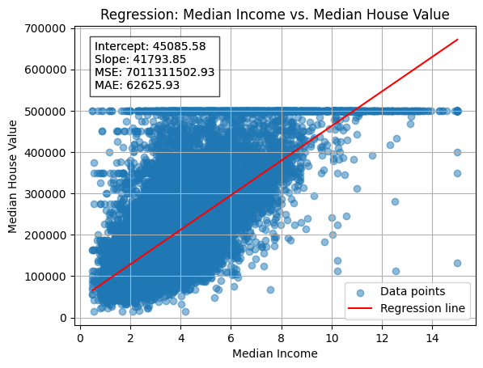

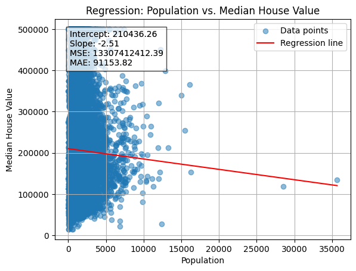

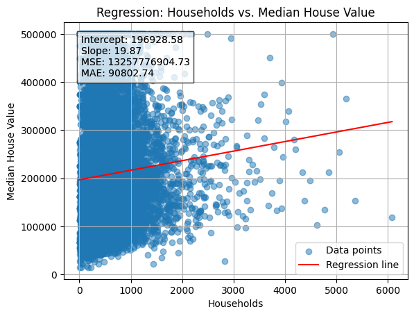

```python
from sklearn.linear_model import LinearRegression
from sklearn.metrics import mean_squared_error, mean_absolute_error
import numpy as np
import matplotlib.pyplot as plt

# Assuming df is your DataFrame with the necessary columns
X_income = data_housing[['median_income']]  # Reshape if needed
y = data_housing['median_house_value']

# Fit the model for Median Income
model_median_income = LinearRegression()
model_median_income.fit(X_income, y)

# Fit the model for Population
X_population = data_housing[['population']]
model_population = LinearRegression()
model_population.fit(X_population, y)

# Fit the model for Number of Households
X_households = data_housing[['households']]
model_households = LinearRegression()
model_households.fit(X_households, y)

# Now you can call the plotting function
# Plot for Median Income
plot_regression(X_income, y, model_median_income, 'Median Income')

# Plot for Population
plot_regression(X_population, y, model_population, 'Population')

# Plot for Number of Households
plot_regression(X_households, y, model_households, 'Households')
```

### **Step-7: Summary**

I built three linear regression models to predict median house value based on median income, population, and number of households. The median income model was the best predictor, showing a strong link between income and house prices. The population model was the weakest, with little connection to house prices. The number of households model showed some relationship, but not as strong as income. Overall, income is the best indicator for predicting house prices in this dataset.

**Key Insights:**

Income is a much better predictor of house prices than population or the number of households. This shows that economic factors are more important for predicting house prices than just demographic numbers.